# mysoln.R

sdhandap

Sun Aug 21 00:22:03 2016

# Project for Practical Machine learning course

The solution follows the below steps

1. Read in the input train and test data and understand it
2. Clean up the data
3. Do Principal component analysis and find the most important variables.
4. Create cross validation datasets
5. Fit two models, LDA and random forests

We select the model with the greater accuracy

```r
library(caret)
library(randomForest)
mainDir="/home/sdhandap/WeightLiftPredict"
setwd(mainDir)
source("helperfuncs.R")
```

## STEP1: Read in the input train and test data and understand it

Read in the training and test data

```r
pmltraindata <- read.table("pml-training.csv",sep=",",header=TRUE)
pmltestdata <- read.table("pml-testing.csv",sep=",",header=TRUE)
```

Explore the structure of the data

```r
preclean_explore(pmltraindata, pmltestdata)
```

```
## =============================
## 'data.frame':    19622 obs. of  160 variables:
##  $ X                       : int  1 2 3 4 5 6 7 8 9 10 ...
##  $ user_name               : Factor w/ 6 levels "adelmo","carlitos",..: 2 2 2 2 2 2 2 2 2 2 ...
##  $ raw_timestamp_part_1    : int  1323084231 1323084231 1323084231 1323084232 1323084232 1323084232 1323084232 1323084232 1323084232 1323084232 ...
##  $ raw_timestamp_part_2    : int  788290 808298 820366 120339 196328 304277 368296 440390 484323 484434 ...
##  $ cvtd_timestamp          : Factor w/ 20 levels "02/12/2011 13:32",..: 9 9 9 9 9 9 9 9 9 9 ...
##  $ new_window              : Factor w/ 2 levels "no","yes": 1 1 1 1 1 1 1 1 1 1 ...
##  $ num_window              : int  11 11 11 12 12 12 12 12 12 12 ...
##  $ roll_belt               : num  1.41 1.41 1.42 1.48 1.48 1.45 1.42 1.42 1.43 1.45 ...
##  $ pitch_belt              : num  8.07 8.07 8.07 8.05 8.07 8.06 8.09 8.13 8.16 8.17 ...
##  $ yaw_belt                : num  -94.4 -94.4 -94.4 -94.4 -94.4 -94.4 -94.4 -94.4 -94.4 -94.4 ...
##  $ total_accel_belt        : int  3 3 3 3 3 3 3 3 3 3 ...
##  $ kurtosis_roll_belt      : Factor w/ 397 levels "","0.000673",..: 1 1 1 1 1 1 1 1 1 1 ...
##  $ kurtosis_picth_belt     : Factor w/ 317 levels "","0.006078",..: 1 1 1 1 1 1 1 1 1 1 ...
```

[output cut: 193 more lines]

## STEP2: Clean up the data

start with eliminating the NA variables

```r
cleantrain <- eliminate_NAs(pmltraindata)
cleantest <- eliminate_NAs(pmltestdata)
```

next eliminating the NULLs

```r
cleantrain <- eliminate_Nulls(cleantrain)
cleantest <- eliminate_Nulls(cleantest)
```

next eliminating the near zero variance variables

```r
cleantrain <- eliminate_zeroVarFactors(cleantrain)
cleantest <- eliminate_zeroVarFactors(cleantest)
```

Drop unnecessary varibles for prediction

```r
answer <- cleantest["problem_id"]
drops <- c("problem_id","X")
cleantest <- cleantest[ , !(names(cleantest) %in% drops)]
cleantrain <- cleantrain[ , !(names(cleantrain) %in% drops)]
#do_some_visualisation(cleantrain)
```

Just explore the data again after exploration

```r
postclean_explore(cleantrain, cleantest)
```

```
## =============================
## 'data.frame':    19622 obs. of  58 variables:
##  $ user_name           : Factor w/ 6 levels "adelmo","carlitos",..: 2 2 2 2 2 2 2 2 2 2 ...
##  $ raw_timestamp_part_1: int  1323084231 1323084231 1323084231 1323084232 1323084232 1323084232 1323084232 1323084232 1323084232 1323084232 ...
##  $ raw_timestamp_part_2: int  788290 808298 820366 120339 196328 304277 368296 440390 484323 484434 ...
##  $ cvtd_timestamp      : Factor w/ 20 levels "02/12/2011 13:32",..: 9 9 9 9 9 9 9 9 9 9 ...
##  $ num_window          : int  11 11 11 12 12 12 12 12 12 12 ...
##  $ roll_belt           : num  1.41 1.41 1.42 1.48 1.48 1.45 1.42 1.42 1.43 1.45 ...
##  $ pitch_belt          : num  8.07 8.07 8.07 8.05 8.07 8.06 8.09 8.13 8.16 8.17 ...
##  $ yaw_belt            : num  -94.4 -94.4 -94.4 -94.4 -94.4 -94.4 -94.4 -94.4 -94.4 -94.4 ...
##  $ total_accel_belt    : int  3 3 3 3 3 3 3 3 3 3 ...
##  $ gyros_belt_x        : num  0 0.02 0 0.02 0.02 0.02 0.02 0.02 0.02 0.03 ...
##  $ gyros_belt_y        : num  0 0 0 0 0.02 0 0 0 0 0 ...
##  $ gyros_belt_z        : num  -0.02 -0.02 -0.02 -0.03 -0.02 -0.02 -0.02 -0.02 -0.02 0 ...
##  $ accel_belt_x        : int  -21 -22 -20 -22 -21 -21 -22 -22 -20 -21 ...
```

[output cut: 108 more lines]

```
## [1] "classe"
##
## Features in testdata that is not in traindata:
```

```
## [1] NA
```

now combine the training and test data so that when we do prediction we dont get the errors like mismatch of type of predictors (“Type of predictors in new data do not match that of the training data.”)

```r
testnumrows <- nrow(cleantest)
cleantest[,"classe"] <- NA
combinedData <- rbind(cleantrain,cleantest)
allrows <- nrow(combinedData)
finaltest <- combinedData[(allrows-testnumrows+1):allrows, ]
trainingset <- combinedData[1:(allrows-testnumrows), ]
```

We are done with the data clean up stage

## STEP3: Do Principal component analysis

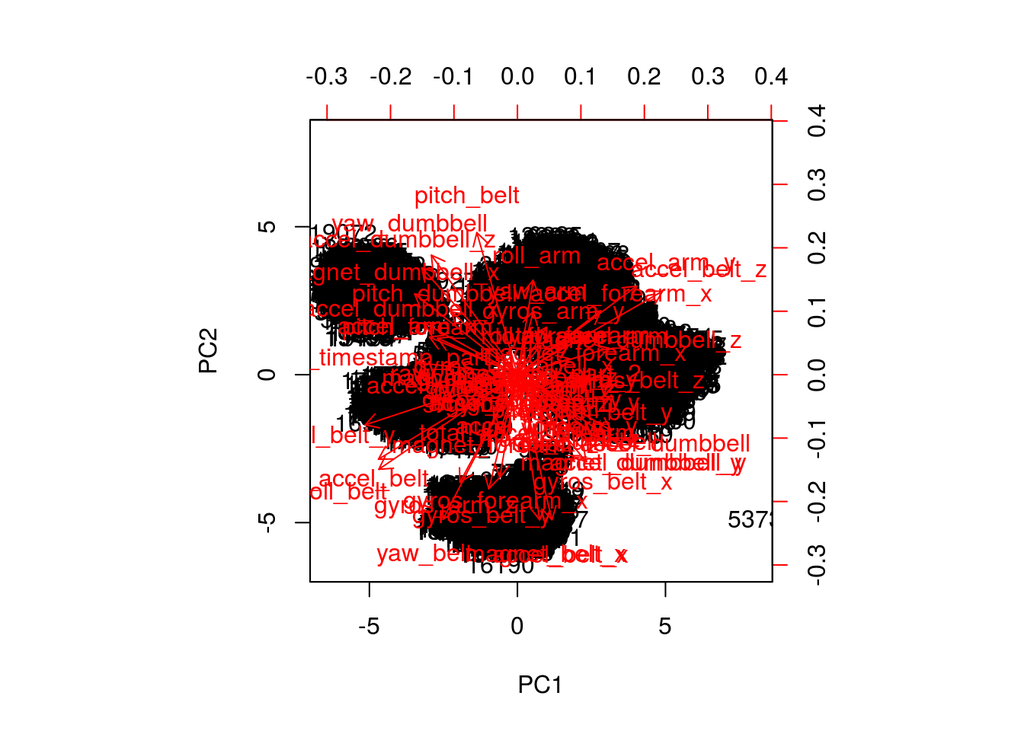

```r
nonNumericVars <- c("user_name","classe","cvtd_timestamp")
pcadata <- combinedData[ , !(names(combinedData) %in% nonNumericVars)]
pca <- prcomp(pcadata, scale = TRUE)
biplot(pca, scale = 0)
```

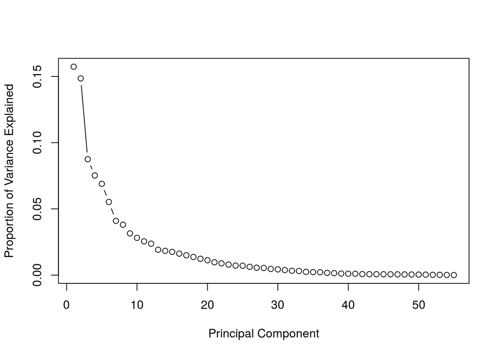

```r
std_dev <- pca$sdev
pr_var <- std_dev^2
prop_varex <- pr_var/sum(pr_var)

plot(prop_varex, xlab = "Principal Component",
           ylab = "Proportion of Variance Explained",
           type = "b")
```

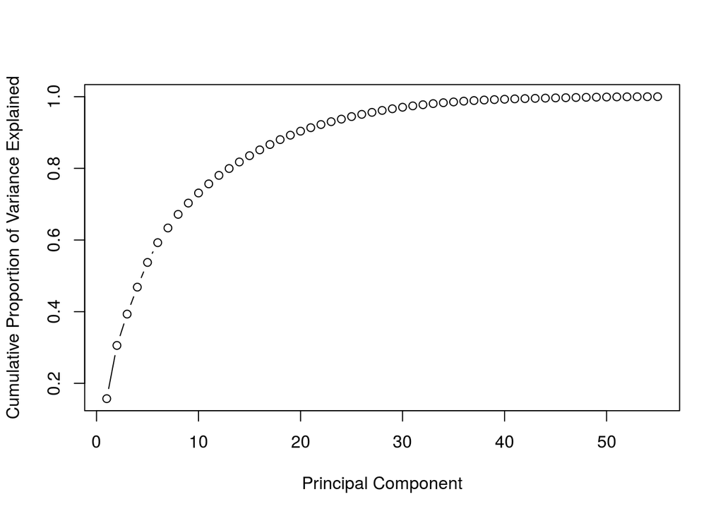

```r
plot(cumsum(prop_varex), xlab = "Principal Component",
           ylab = "Cumulative Proportion of Variance Explained",
           type = "b")
```

```r
selectcols = which(prop_varex >= 0.002)
dataAfterPCA <- pcadata[,selectcols]
pr_cols <- names(dataAfterPCA)
pr_cols <- c(pr_cols, "classe")



train.pca.data <- trainingset[,(names(trainingset) %in% pr_cols)]
test.pca.data <- finaltest[,(names(finaltest) %in% pr_cols)]
```

Now we are done with the principal component analysis. Next step is to split the data for cross validatiopn do the simple train test and validation split

## STEP4: Create cross validation datasets

```r
training.rows <- createDataPartition(train.pca.data$classe,  p = 0.8, list = FALSE)


train.batch <- train.pca.data[training.rows, ]
test.batch <- train.pca.data[-training.rows, ]
```

Now we have the data split into three: the train.batch, test.batch and the finaltest dataset

## STEP5: Model creation and Validation

```r
dependentvarname <- "classe"
AllVariables <- names(train.pca.data)
PredictorVariables <- setdiff(AllVariables, dependentvarname)
Formula <- formula(paste( paste(dependentvarname, " ~ ", sep =""),
                            paste(PredictorVariables, collapse=" + ")))
print(Formula)
```

```
## classe ~ raw_timestamp_part_1 + raw_timestamp_part_2 + num_window +
##     roll_belt + pitch_belt + yaw_belt + total_accel_belt + gyros_belt_x +
##     gyros_belt_y + gyros_belt_z + accel_belt_x + accel_belt_y +
##     accel_belt_z + magnet_belt_x + magnet_belt_y + magnet_belt_z +
##     roll_arm + pitch_arm + yaw_arm + total_accel_arm + gyros_arm_x +
##     gyros_arm_y + gyros_arm_z + accel_arm_x + accel_arm_y + accel_arm_z +
##     magnet_arm_x + magnet_arm_y + magnet_arm_z + roll_dumbbell +
##     pitch_dumbbell + yaw_dumbbell + total_accel_dumbbell + gyros_dumbbell_x +
##     gyros_dumbbell_y + gyros_dumbbell_z
```

Fit the random forest model

```r
rf_fit <- randomForest(Formula,
                       data=train.batch,
                       importance=TRUE,
                       ntree=2000)
pred.rf <- predict(rf_fit, test.batch)
confusionMatrix(pred.rf, test.batch$classe)
```

```
## Confusion Matrix and Statistics
##
##           Reference
## Prediction    A    B    C    D    E
##          A 1116    1    0    0    0
##          B    0  758    2    0    0
##          C    0    0  681    2    0
##          D    0    0    1  641    0
##          E    0    0    0    0  721
##
## Overall Statistics
##
##                Accuracy : 0.9985
##                  95% CI : (0.9967, 0.9994)
##     No Information Rate : 0.2845
##     P-Value [Acc > NIR] : < 2.2e-16
##
##                   Kappa : 0.9981
##  Mcnemar's Test P-Value : NA
##
## Statistics by Class:
##
##                      Class: A Class: B Class: C Class: D Class: E
## Sensitivity            1.0000   0.9987   0.9956   0.9969   1.0000
## Specificity            0.9996   0.9994   0.9994   0.9997   1.0000
## Pos Pred Value         0.9991   0.9974   0.9971   0.9984   1.0000
## Neg Pred Value         1.0000   0.9997   0.9991   0.9994   1.0000
## Prevalence             0.2845   0.1935   0.1744   0.1639   0.1838
## Detection Rate         0.2845   0.1932   0.1736   0.1634   0.1838
## Detection Prevalence   0.2847   0.1937   0.1741   0.1637   0.1838
## Balanced Accuracy      0.9998   0.9990   0.9975   0.9983   1.0000
```

```r
accuracy.rf <- (round(mean(pred.rf == test.batch$classe),3))
```

The accuracy in the random forest model

```r
print(accuracy.rf)
```

```
## [1] 0.998
```

Fit the Linear discriminant analysis model

```r
model_lda <- train(Formula, method = "lda", data = train.batch)
pred.lda <- predict(model_lda, test.batch)
confusionMatrix(pred.lda, test.batch$classe)
```

```
## Confusion Matrix and Statistics
##
##           Reference
## Prediction   A   B   C   D   E
##          A 793 104 212 109  72
##          B  84 488 107  37 127
##          C  97 117 258  46  65
##          D 132  30  93 409  91
##          E  10  20  14  42 366
##
## Overall Statistics
##
##                Accuracy : 0.5899
##                  95% CI : (0.5743, 0.6053)
##     No Information Rate : 0.2845
##     P-Value [Acc > NIR] : < 2.2e-16
##
##                   Kappa : 0.4784
##  Mcnemar's Test P-Value : < 2.2e-16
##
## Statistics by Class:
##
##                      Class: A Class: B Class: C Class: D Class: E
## Sensitivity            0.7106   0.6430  0.37719   0.6361   0.5076
## Specificity            0.8229   0.8878  0.89966   0.8945   0.9731
## Pos Pred Value         0.6147   0.5789  0.44254   0.5417   0.8097
## Neg Pred Value         0.8773   0.9120  0.87246   0.9261   0.8977
## Prevalence             0.2845   0.1935  0.17436   0.1639   0.1838
## Detection Rate         0.2021   0.1244  0.06577   0.1043   0.0933
## Detection Prevalence   0.3288   0.2149  0.14861   0.1925   0.1152
## Balanced Accuracy      0.7668   0.7654  0.63843   0.7653   0.7404
```

```r
accuracy.lda <-(round(mean(pred.lda == test.batch$classe),3))
```

The accuracy in the LDA model is

```r
print(accuracy.lda)
```

```
## [1] 0.59
```

```r
if(accuracy.rf >= accuracy.lda) {

  #'
  #' Select Random Forest model for the final prediction
  #'
  #'
  pred.final <- predict(rf_fit, finaltest)


}else {
  #'
  #' Select LDA model for the final prediction
  #'
  #'
  pred.final <- predict(model_lda, finaltest)
}
```

This is the final prediction output.

```r
print(pred.final)
```

```
## 19623 19624 19625 19626 19627 19628 19629 19630 19631 19632 19633 19634
##     B     A     B     A     A     E     D     B     A     A     B     C
## 19635 19636 19637 19638 19639 19640 19641 19642
##     B     A     E     E     A     B     B     B
## Levels: A B C D E
```